# Part II - Ford GoBike Dataset Explanatory Visualizations Presentation

## by Thárcyla Mourão

## Dataset Overview

Ford GoBike was a bike-sharing system that covered the greater San Francisco Bay area from [2017](https://media.ford.com/content/fordmedia/fna/us/en/news/2017/06/27/ford-gobike-launching-in-bay-area-bike-sharing.html) to [2019](https://techcrunch.com/2019/06/11/lyft-deploys-its-pink-wheeled-bikes-and-rebrands-ford-gobike-as-bay-wheels/). This dataset has information on trips taken on February 2019.

Among the information available in the dataset, I had start time, end time, names of the start and end stations, gender, birth year of users, among others.

The objective of this project as a whole was to create a series of exploratory and explanatory visualizations related to my main variable of interest, **trip duration**. The first part covered the exploratory charts, while the second part covered the explanatory data visualizations.

## Investigation Overview

In this presentation, I aim to focus on what factors influence trip duration. I'll start the presentation with a histogram for the trip duration distribution given its importance to this project.

Then, I'll move on to a heat map illustrating the relationship between trip duration and age, given that analysis showed that most of the trips were taken by people in their 20s to 40s. The plot also shows that most of the trips in that age bracket (in the whole dataset, really), are trips with less than 1,000 seconds (around 15 minutes).

Lastly, I'll then finish the presentation with a line plot of the average trip duration by hour, for every gender. This visualization was chosen since this single plot encapsulate a lot of the insights I've found throughout the exploration of this dataset.

## Distribution of Trip Duration

Making the log transformation made analysis easier. The resulting distribution resembles a normal one. Most trips take between 300 and 1000 seconds, i.e., between 5 and 15 minutes.

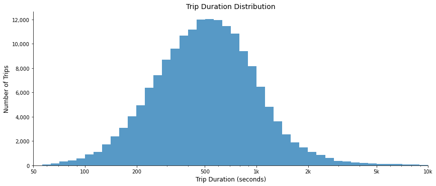

## Trip Duration vs. Age

Considering trips of up to 3600 seconds (an hour), the majority of them were taken by people in the 18-40 age bracket. The plot also showed that most of the trips in that age bracket, are trips with less than 1,000 seconds (around 15 minutes).

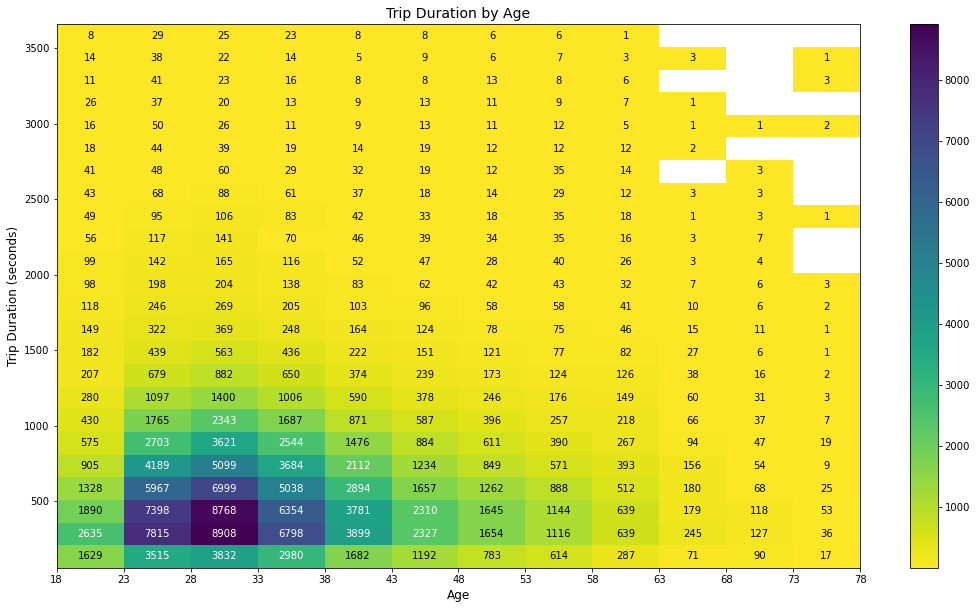

## Trip Start Hour vs. Average Trip Duration by Gender

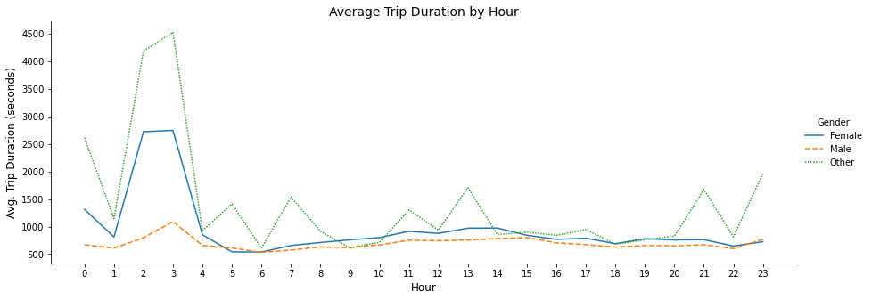